# DATA622 | Machine Learning and Big Data

Gabriella Martinez

3/5/2023

# Assignment 1

**Pre-Work**  
1. Visit the following website and explore the range of sizes of this dataset (from 100 to 5 million records):  
https://excelbianalytics.com/wp/downloads-18-sample-csv-files-data-sets-for-testing-sales/ or  
(new) https://www.kaggle.com/datasets  
2. Select 2 files to download. Based on your computer’s capabilities (memory, CPU), select 2 files you can handle (recommended one small, one large)  
3. Download the files  
4. Review the structure and content of the tables, and think about the data sets (structure, size, dependencies, labels, etc)  
5. Consider the similarities and differences in the two data sets you have downloaded  
6. Think about how to analyze and predict an outcome based on the datasets available  
7. Based on the data you have, think which two machine learning algorithms presented so far could be used to analyze the data

**Deliverable**  
1. Essay (minimum 500 word document). Write a short essay explaining your selection of algorithms and how they relate to the data and what you are trying to do.  
2. Exploratory Analysis using R or Python (submit code + errors + analysis as notebook or copy/paste to document. Explore how to analyze and predict an outcome based on the data available. This will be an exploratory exercise, so feel free to show errors and warnings that raise during the analysis. Test the code with both datasets selected and compare the results.

**Answer questions such as:**  
1. Are the columns of your data correlated?  
2. Are there labels in your data? Did that impact your choice of algorithm?  
3. What are the pros and cons of each algorithm you selected?  
4. How your choice of algorithm relates to the datasets (was your choice of algorithm impacted by the datasets you chose)?  
5. Which result will you trust if you need to make a business decision?  
6. Do you think an analysis could be prone to errors when using too much data, or when using the least amount possible?  
7. How does the analysis between data sets compare?  
Develop your exploratory analysis of the data and the essay in the following 2 weeks.

# Packages

```r
library(readr)
library(tidyverse)
library(tidymodels)
library(psych)
library(caret)
library(rpart)
library(rpart.plot)
library(corrplot)
library(RColorBrewer)
library(labelled)
library(ggplot2)
library(ggforce)
```

# Load Data

```r
df1k <- read.csv("https://raw.githubusercontent.com/gabbypaola/DATA622/main/HW%201/1000%20Sales%20Records.csv")
df100k <- read.csv("https://raw.githubusercontent.com/gabbypaola/DATA622/main/HW%201/100000%20Sales%20Records.csv")
```

# Exploratory Data Analysis

First, exploratory data analysis is conducted to get acquainted with the two Sales datasets selected from https://excelbianalytics.com/wp/downloads-18-sample-csv-files-data-sets-for-testing-sales/.

## Dimensions, Variable Types, Labels, Levels, and Frequencies

The dimensions of the 1k data set are checked. The dataset contains 1000 rows, and 14 columns, or predictors. There are 7 character, 2 integer, and 5 double type variables. The `glimpse()` output shows us the first few observation of each variable. There are two geographical variables one for Region, and another for each specific country. Item.Type refers to the type of items sold, Sales.Channel refers to the sales method, whether the sale was conducted online or offline, meaning an in-store purchase.

The `look_for()` function from the labelled package shows us each variable, their label (if available), column type, as well as the values for any factor type variables. The function produces no labels, and no values as none of the variables are coded as factor types.

[^1]

```r
print("Dimensions")
```

```
## [1] "Dimensions"
```

```r
glimpse(df1k)
```

```
## Rows: 1,000
## Columns: 14
## $ Region         <chr> "Middle East and North Africa", "North America", "Middl~
## $ Country        <chr> "Libya", "Canada", "Libya", "Japan", "Chad", "Armenia",~
## $ Item.Type      <chr> "Cosmetics", "Vegetables", "Baby Food", "Cereal", "Frui~
## $ Sales.Channel  <chr> "Offline", "Online", "Offline", "Offline", "Offline", "~
## $ Order.Priority <chr> "M", "M", "C", "C", "H", "H", "H", "M", "H", "H", "M", ~
## $ Order.Date     <chr> "10/18/2014", "11/7/2011", "10/31/2016", "4/10/2010", "~
## $ Order.ID       <int> 686800706, 185941302, 246222341, 161442649, 645713555, ~
## $ Ship.Date      <chr> "10/31/2014", "12/8/2011", "12/9/2016", "5/12/2010", "8~
## $ Units.Sold     <int> 8446, 3018, 1517, 3322, 9845, 9528, 2844, 7299, 2428, 4~
## $ Unit.Price     <dbl> 437.20, 154.06, 255.28, 205.70, 9.33, 205.70, 205.70, 1~
## $ Unit.Cost      <dbl> 263.33, 90.93, 159.42, 117.11, 6.92, 117.11, 117.11, 35~
## $ Total.Revenue  <dbl> 3692591.20, 464953.08, 387259.76, 683335.40, 91853.85, ~
## $ Total.Cost     <dbl> 2224085.18, 274426.74, 241840.14, 389039.42, 68127.40, ~
## $ Total.Profit   <dbl> 1468506.02, 190526.34, 145419.62, 294295.98, 23726.45, ~
```

```r
print("Labels")
```

```
## [1] "Labels"
```

```r
look_for(df1k)
```

```
##  pos variable       label col_type values
##  1   Region         —     chr
##  2   Country        —     chr
##  3   Item.Type      —     chr
##  4   Sales.Channel  —     chr
##  5   Order.Priority —     chr
##  6   Order.Date     —     chr
##  7   Order.ID       —     int
##  8   Ship.Date      —     chr
##  9   Units.Sold     —     int
##  10  Unit.Price     —     dbl
##  11  Unit.Cost      —     dbl
##  12  Total.Revenue  —     dbl
##  13  Total.Cost     —     dbl
##  14  Total.Profit   —     dbl
```

Next, using the `unique()` and `length()` functions are used to investigate the geographic variables. There are 7 Regions and 185 countries spanning the 1k dataset.

```r
unique(df1k$Region)
```

```
## [1] "Middle East and North Africa"      "North America"
## [3] "Asia"                              "Sub-Saharan Africa"
## [5] "Europe"                            "Central America and the Caribbean"
## [7] "Australia and Oceania"
```

```r
length(unique(df1k$Country))
```

```
## [1] 185
```

The `table()` function is used to create contingency, or frequency tables of some of the character variables, Item.Type and Sales.Channel. The sorted frequency table shows the top three items of the total 12 types in the 1k dataset are beverages, vegetables, followed by office supplies.

```r
table(df1k$Item.Type)[order(table(df1k$Item.Type),decreasing = TRUE)]
```

```
##
##       Beverages      Vegetables Office Supplies       Baby Food   Personal Care
##             101              97              89              87              87
##          Snacks          Cereal         Clothes            Meat       Household
##              82              79              78              78              77
##       Cosmetics          Fruits
##              75              70
```

```r
table(df1k$Sales.Channel)
```

```
##
## Offline  Online
##     520     480
```

Following the EDA for the 1k dataset, is the EDA for the 100k dataset. The 100k dataset contains 100,000 rows and 14 columns. Similar to the 1k dataset, in the 100k dataset there are 7 character, 2 integer, and 5 double type variables. The `glimpse()` output shows us the first few observation of each variable. There are two geographical variables one for Region, and another for each specific country. Item.Type refers to the type of items sold, Sales.Channel refers to the sales method, whether the sale was conducted online or offline, meaning an in-store purchase.

The `look_for()` function from the labelled package shows us each variable, their label (if available), column type, as well as the values for any factor type variables. The function produces no labels, and no values as none of the variables are coded as factor types.

```r
print("Dimensions")
```

```
## [1] "Dimensions"
```

```r
glimpse(df100k)
```

```
## Rows: 100,000
## Columns: 14
## $ Region         <chr> "Middle East and North Africa", "Central America and th~
## $ Country        <chr> "Azerbaijan", "Panama", "Sao Tome and Principe", "Sao T~
## $ Item.Type      <chr> "Snacks", "Cosmetics", "Fruits", "Personal Care", "Hous~
## $ Sales.Channel  <chr> "Online", "Offline", "Offline", "Online", "Offline", "O~
## $ Order.Priority <chr> "C", "L", "M", "M", "H", "C", "M", "C", "H", "H", "C", ~
## $ Order.Date     <chr> "10/8/2014", "2/22/2015", "12/9/2015", "9/17/2014", "2/~
## $ Order.ID       <int> 535113847, 874708545, 854349935, 892836844, 129280602, ~
## $ Ship.Date      <chr> "10/23/2014", "2/27/2015", "1/18/2016", "10/12/2014", "~
## $ Units.Sold     <int> 934, 4551, 9986, 9118, 5858, 1149, 7964, 6307, 8217, 27~
## $ Unit.Price     <dbl> 152.58, 437.20, 9.33, 81.73, 668.27, 109.28, 437.20, 9.~
## $ Unit.Cost      <dbl> 97.44, 263.33, 6.92, 56.67, 502.54, 35.84, 263.33, 6.92~
## $ Total.Revenue  <dbl> 142509.72, 1989697.20, 93169.38, 745214.14, 3914725.66,~
## $ Total.Cost     <dbl> 91008.96, 1198414.83, 69103.12, 516717.06, 2943879.32, ~
## $ Total.Profit   <dbl> 51500.76, 791282.37, 24066.26, 228497.08, 970846.34, 84~
```

```r
print("Labels")
```

```
## [1] "Labels"
```

```r
look_for(df100k)
```

```
##  pos variable       label col_type values
##  1   Region         —     chr
##  2   Country        —     chr
##  3   Item.Type      —     chr
##  4   Sales.Channel  —     chr
##  5   Order.Priority —     chr
##  6   Order.Date     —     chr
##  7   Order.ID       —     int
##  8   Ship.Date      —     chr
##  9   Units.Sold     —     int
##  10  Unit.Price     —     dbl
##  11  Unit.Cost      —     dbl
##  12  Total.Revenue  —     dbl
##  13  Total.Cost     —     dbl
##  14  Total.Profit   —     dbl
```

As above, using the `unique()` and `length()` functions are used to investigate the geographic variables. There are also 7 Regions and 185 countries spanning the 100k dataset.

```r
unique(df100k$Region)
```

```
## [1] "Middle East and North Africa"      "Central America and the Caribbean"
## [3] "Sub-Saharan Africa"                "Europe"
## [5] "Asia"                              "Australia and Oceania"
## [7] "North America"
```

```r
length(unique(df100k$Country))
```

```
## [1] 185
```

Once again the `table()` function is used to create contingency, or frequency tables of some of the character variables, Item.Type and Sales.Channel in the 100k dataset. The sorted frequency table shows the top three items of the total 12 types in the 100k dataset are office supplies, cereal, and baby food.

```r
table(df100k$Item.Type)[order(table(df100k$Item.Type),decreasing = TRUE)]
```

```
##
## Office Supplies          Cereal       Baby Food       Cosmetics   Personal Care
##            8426            8421            8407            8370            8364
##            Meat          Snacks         Clothes      Vegetables       Household
##            8320            8308            8304            8282            8278
##          Fruits       Beverages
##            8262            8258
```

```r
table(df100k$Sales.Channel)
```

```
##
## Offline  Online
##   49946   50054
```

## Variable Dependencies and Definitions

Both datasets contain the same information, only differing in the amount of observations. As such, below are the variable dependencies and definitions that are applicable to both the 1k and 100k dataset.

`Total.Cost` = `Units.Sold` * `Unit.Cost`  
`Total.Revenue` = `Units.Sold` * `Unit.Price`  
`Total.Profit` = `Total.Revenue` - `Total.Cost` (where `Total.Cost` and `Total.Revenue` depend on `Units.Sold`, `Unit.Cost`, and `Unit.Price`)

`Order.Priority`: C(Critical), H(High), M(Medium), and L(Low)

## Variable Type Conversions

Variable types are converted to ensure the models created use the correct type of variables. Variable conversion also aids in the preprocessing by ensuring originally numeric variables such as `Order.ID` are not inadvertently normalized or used in the modelling stage. There are a number of advantages to converting categorical variables to factor variables. Perhaps the most important advantage is that they can be used in statistical modeling where they will be implemented correctly, i.e., they will then be assigned the correct number of degrees of freedom. [^2]

```r
df1k[['Order.Date']] <- as.Date(df1k[['Order.Date']], "%m/%d/%Y")
df1k[['Ship.Date']] <- as.Date(df1k[['Ship.Date']], "%m/%d/%Y")

df100k[['Order.Date']] <- as.Date(df100k[['Order.Date']], "%m/%d/%Y")
df100k[['Ship.Date']] <- as.Date(df100k[['Ship.Date']], "%m/%d/%Y")

df1k[['Sales.Channel']] <- as.factor(df1k[['Sales.Channel']])
df100k[['Sales.Channel']] <- as.factor(df100k[['Sales.Channel']])

df1k[['Order.Priority']] <- as.factor(df1k[['Order.Priority']])
df100k[['Order.Priority']] <- as.factor(df100k[['Order.Priority']])

df1k[['Item.Type']] <- as.factor(df1k[['Item.Type']])
df100k[['Item.Type']] <- as.factor(df100k[['Item.Type']])

df1k[['Region']] <- as.factor(df1k[['Region']])
df100k[['Region']] <- as.factor(df100k[['Region']])

df1k[['Country']] <- as.factor(df1k[['Country']])
df100k[['Country']] <- as.factor(df100k[['Country']])

df1k[['Order.ID']] <- as.character(df1k[['Order.ID']])
df100k[['Order.ID']] <- as.character(df100k[['Order.ID']])
```

```r
levels(df1k$Sales.Channel)
```

```
## [1] "Offline" "Online"
```

```r
levels(df100k$Sales.Channel)
```

```
## [1] "Offline" "Online"
```

## Missing Data

Next the data is checked for any missing values.

The below shows no missing values for the 1k dataset.

```r
colSums(is.na(df1k))
```

```
##         Region        Country      Item.Type  Sales.Channel Order.Priority
##              0              0              0              0              0
##     Order.Date       Order.ID      Ship.Date     Units.Sold     Unit.Price
##              0              0              0              0              0
##      Unit.Cost  Total.Revenue     Total.Cost   Total.Profit
##              0              0              0              0
```

As in the 1k dataset, there are no missing values for the 100k dataset.

```r
colSums(is.na(df100k))
```

```
##         Region        Country      Item.Type  Sales.Channel Order.Priority
##              0              0              0              0              0
##     Order.Date       Order.ID      Ship.Date     Units.Sold     Unit.Price
##              0              0              0              0              0
##      Unit.Cost  Total.Revenue     Total.Cost   Total.Profit
##              0              0              0              0
```

## Distributions

```r
#select numeric columns 1k
df1k_n <- df1k %>%
   keep(is.numeric)
  #  %>% select(-Order.ID)

#select numeric columns 100k
df100k_n <- df100k %>%
  keep(is.numeric)
# %>%
#   select(-Order.ID)
```

From the `describe()` output for the 1k dataset, it is noted that the numeric variables have wide ranges. This will be taken care of through normalization to scale the variables in the preprocessing stage prior to running models. Futhermore, through the use of the graphs created for each, it is noted that `Total.Cost`, `Total.Profit`, and `Total.Revenue` are right skewed and the distributions for `Unit.Cost`, `Unit.Price`, and `Units.Sold` are multimodal. `Unit.Cost` shows four modes, `Unit.Price` shows three modes, and `Units.Sold` shows two modes.

```r
#stats
describe(df1k_n, fast=TRUE) %>%
  select(c(-vars,-n))
```

```
##                     mean         sd     min        max      range       se
## Units.Sold       5053.99    2901.38   13.00    9998.00    9985.00    91.75
## Unit.Price        262.11     216.02    9.33     668.27     658.94     6.83
## Unit.Cost         184.97     175.29    6.92     524.96     518.04     5.54
## Total.Revenue 1327321.84 1486514.56 2043.25 6617209.54 6615166.29 47007.72
## Total.Cost     936119.23 1162570.75 1416.75 5204978.40 5203561.65 36763.72
## Total.Profit   391202.61  383640.19  532.61 1726181.36 1725648.75 12131.77
```

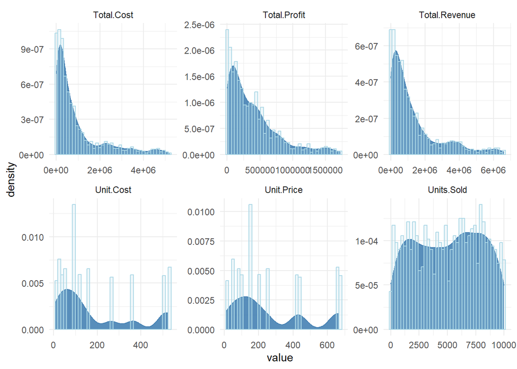

```r
#distribution
df1k_n %>%
  gather(variable, value, 1:6) %>%
  ggplot(aes(value)) +
    facet_wrap(~variable, scales = "free") +
    geom_density(fill = "steelblue", alpha=0.9, color="steelblue") +
    geom_histogram(aes(y=after_stat(density)), alpha=0.2, fill = "lightblue",
                   color="lightblue", position="identity", bins = 40) +
    theme_minimal()
```

```r
#stats
describe(df100k_n, fast=TRUE) %>%
  select(c(-vars,-n))
```

```
##                     mean         sd   min        max      range      se
## Units.Sold       5001.45    2884.58  1.00   10000.00    9999.00    9.12
## Unit.Price        266.70     216.94  9.33     668.27     658.94    0.69
## Unit.Cost         188.02     175.71  6.92     524.96     518.04    0.56
## Total.Revenue 1336066.73 1471767.59 18.66 6682700.00 6682681.34 4654.14
## Total.Cost     941975.49 1151828.43 13.84 5249075.04 5249061.20 3642.40
## Total.Profit   394091.24  379598.60  4.82 1738700.00 1738695.18 1200.40
```

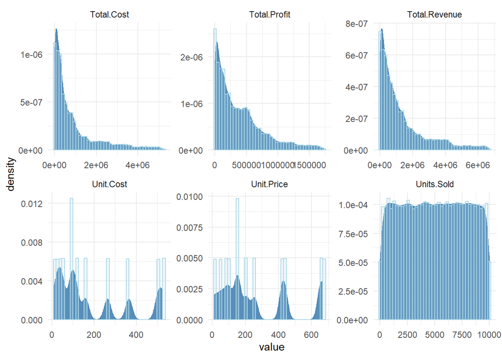

```r
#distributions
df100k_n %>%
  gather(variable, value, 1:6) %>%
  ggplot(aes(value)) +
    facet_wrap(~variable, scales = "free") +
    geom_density(fill = "steelblue", alpha=0.9, color="steelblue") +
    geom_histogram(aes(y=after_stat(density)), alpha=0.2, fill = "lightblue",
                   color="lightblue", position="identity",bins = 40) +
    theme_minimal()
```

## Correlations

Subsequently, the correlations between numeric variables are examined. It is important to investigate the correlations between the independent variables to avoid multicollinearity. Multicollinearity occurs when two or more independent variables are highly correlated to one another. When two (or more) independent variables are highly correlated one cannot individually determine the impact of individual variables on the dependent variable.

Multicollinearity can be a problem in a regression model when using algorithms such as OLS (ordinary least squares). This is because the estimated regression coefficients become unstable and difficult to interpret in the presence of multicollinearity.

When multicollinearity is present, the estimated regression coefficients may become large and unpredictable, leading to unreliable inferences about the effects of the predictor variables on the response variable. Therefore, it is important to check for multicollinearity and consider using other regression techniques that can handle this problem, such as ridge regression or principal component regression or make a decision about dropping highly correlated independent variables entirely.

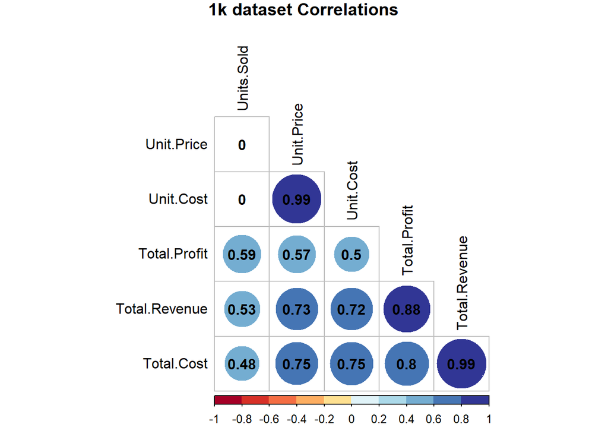

```r
cor(df1k_n) %>%
  corrplot(tl.col = 'black', diag=FALSE, type="lower",
           order="hclust", addCoef.col = "black",
           #mar argument fixes title positioning
           title="1k dataset Correlations", mar=c(0,0,1,0),
           col=brewer.pal(n=10, name="RdYlBu"))
```

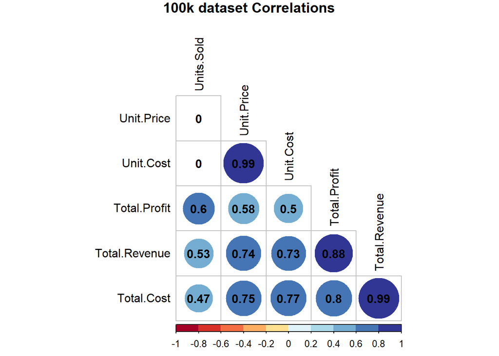

```r
cor(df100k_n) %>%
  corrplot(tl.col = 'black', diag=FALSE, type="lower",
           order="hclust", addCoef.col = "black",
           title="100k dataset Correlations",mar=c(0,0,1,0),
           col=brewer.pal(n=10, name="RdYlBu"))
```

The correlation plots for both the 1k and 100k dataset show nearly identical correlation coefficients. Variables with weak correlation (i.e., 0<=|r|<0.3) [^3] between Unit.Price, Unit.Cost, and Units.Sold. Moderate correlation (i.e., 0.3≤|r|<0.7) can be seen between Total.Profit, Total.Revenue, Total.Cost and Units.Sold as well as between Unit.Price, Unit.Cost and Total.Profit. High correlation (i.e., |r|>=0.7) can be seen in the remaining pairs, especially between Unit.Price and Unit.Cost, Total.Profit and Total.Revenue, Total.Cost and Total.Revenue.

## VIF Scores

Another detection method for multicoliniarity is through the use of the VIF (Variance Inflation Factor) score. The variance inflation factor (or VIF), measures how much the variance of a regression coefficient is inflated due to multicollinearity in the model. The smallest possible value of VIF is one (absence of multicollinearity). As a rule of thumb, a VIF value that exceeds 5 or 10 indicates a problematic amount of collinearity. [^4]

```r
set.seed(145)

training.samples <- df1k_n$Total.Revenue %>%
  createDataPartition(p = 0.8, list = FALSE)
train.data  <- df1k_n[training.samples, ]
test.data <- df1k_n[-training.samples, ]
```

```r
# Build the model
#train.data1 <-train.data #%>% select(c(-Total.Profit,-Total.Cost, -Unit.Price))
model1<- lm(Total.Revenue~., data=train.data )

summary(model1)
```

```
##
## Call:
## lm(formula = Total.Revenue ~ ., data = train.data)
##
## Residuals:
##        Min         1Q     Median         3Q        Max
## -1.132e-08 -9.590e-11  5.400e-12  1.020e-10  1.483e-08
##
## Coefficients:
##                Estimate Std. Error    t value Pr(>|t|)
## (Intercept)  -2.279e-09  8.965e-11 -2.543e+01   <2e-16 ***
## Units.Sold    3.953e-13  1.507e-14  2.623e+01   <2e-16 ***
## Unit.Price    2.142e-12  1.480e-12  1.447e+00   0.1482
## Unit.Cost     4.097e-12  1.819e-12  2.252e+00   0.0246 *
## Total.Cost    1.000e+00  7.202e-17  1.388e+16   <2e-16 ***
## Total.Profit  1.000e+00  2.475e-16  4.040e+15   <2e-16 ***
## ---
## Signif. codes:  0 '***' 0.001 '**' 0.01 '*' 0.05 '.' 0.1 ' ' 1
##
## Residual standard error: 6.964e-10 on 794 degrees of freedom
## Multiple R-squared:      1,  Adjusted R-squared:      1
## F-statistic: 7.297e+32 on 5 and 794 DF,  p-value: < 2.2e-16
```

```r
# Make predictions
predictions <- model1 %>% predict(test.data)
# Model performance
data.frame(
  RMSE = RMSE(predictions, test.data$Total.Revenue),
  R2 = R2(predictions, test.data$Total.Revenue)
)
```

```
##          RMSE R2
## 1 8.41499e-10  1
```

As expected from the correlation plot, multicoliniarity is detected through the resulting VIF scores for the 1k dataset. Four of the five numeric variables have VIF scores higher than 10, two of which are exorbitantly high with VIF scores of over 170 (`Unit.Price` and `Unit.Cost`) as seen below.

```r
car::vif(model1)
```

```
##   Units.Sold   Unit.Price    Unit.Cost   Total.Cost Total.Profit
##     3.129983   172.608852   171.720000    11.557770    14.749576
```

```r
set.seed(145)

training.samples2 <- df100k_n$Total.Revenue %>%
  createDataPartition(p = 0.8, list = FALSE)
train.data2  <- df100k_n[training.samples2, ]
test.data2 <- df100k_n[-training.samples2, ]
```

```r
# Build the model
#%>% select(c(-Total.Profit,-Total.Cost, -Unit.Price))
model2<- lm(Total.Revenue~., data=train.data2 )

summary(model2)
```

```
##
## Call:
## lm(formula = Total.Revenue ~ ., data = train.data2)
##
## Residuals:
##        Min         1Q     Median         3Q        Max
## -3.462e-06  0.000e+00  1.000e-10  2.000e-10  1.824e-06
##
## Coefficients:
##                Estimate Std. Error    t value Pr(>|t|)
## (Intercept)  -1.636e-08  2.186e-10 -7.486e+01  < 2e-16 ***
## Units.Sold    2.988e-13  3.800e-14  7.863e+00 3.81e-15 ***
## Unit.Price   -1.142e-10  3.350e-12 -3.409e+01  < 2e-16 ***
## Unit.Cost     9.443e-11  4.139e-12  2.282e+01  < 2e-16 ***
## Total.Cost    1.000e+00  1.740e-16  5.746e+15  < 2e-16 ***
## Total.Profit  1.000e+00  5.813e-16  1.720e+15  < 2e-16 ***
## ---
## Signif. codes:  0 '***' 0.001 '**' 0.01 '*' 0.05 '.' 0.1 ' ' 1
##
## Residual standard error: 1.719e-08 on 79995 degrees of freedom
## Multiple R-squared:      1,  Adjusted R-squared:      1
## F-statistic: 1.175e+32 on 5 and 79995 DF,  p-value: < 2.2e-16
```

```r
# Make predictions
predictions2 <- model2 %>% predict(test.data2)
# Model performance
data.frame(
  RMSE = RMSE(predictions2, test.data2$Total.Revenue),
  R2 = R2(predictions2, test.data2$Total.Revenue)
)
```

```
##          RMSE R2
## 1 1.72024e-08  1
```

```r
car::vif(model1)
```

```
##   Units.Sold   Unit.Price    Unit.Cost   Total.Cost Total.Profit
##     3.129983   172.608852   171.720000    11.557770    14.749576
```

# Preprocessing

## Normalization

Next, the data is normalized in preparation for modelling. [^5] When variables are measured at different scales, they often do not contribute equally to the analysis. For example, if the values of one variable range from 0 to 100,000 and the values of another variable range from 0 to 100, the variable with the larger range will be given a larger weight in the analysis. By normalizing the variables, we can be sure that each variable contributes equally to the analysis.

```r
#define Min-Max normalization function
min_max_norm <- function(x) {
    (x - min(x)) / (max(x) - min(x))
}

#apply Min-Max normalization to numeric columns
df1k_norm <- as.data.frame(lapply(df1k_n, min_max_norm))

df100k_norm <- as.data.frame(lapply(df100k_n, min_max_norm))
```

```r
#stats
describe(df1k_norm, fast=TRUE) %>%
  select(c(-vars,-n))
```

```
##               mean   sd min max range   se
## Units.Sold    0.50 0.29   0   1     1 0.01
## Unit.Price    0.38 0.33   0   1     1 0.01
## Unit.Cost     0.34 0.34   0   1     1 0.01
## Total.Revenue 0.20 0.22   0   1     1 0.01
## Total.Cost    0.18 0.22   0   1     1 0.01
## Total.Profit  0.23 0.22   0   1     1 0.01
```

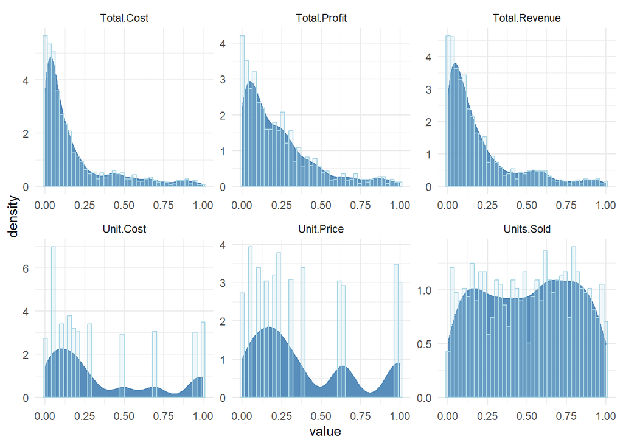

```r
#distribution
df1k_norm %>%
  gather(variable, value, 1:6) %>%
  ggplot(aes(value)) +
    facet_wrap(~variable, scales = "free") +
    geom_density(fill = "steelblue", alpha=0.9, color="steelblue") +
    geom_histogram(aes(y=after_stat(density)), alpha=0.2, fill = "lightblue",
                   color="lightblue", position="identity", bins = 40) +
    theme_minimal()
```

```r
#stats
describe(df100k_norm, fast=TRUE) %>%
  select(c(-vars,-n))
```

```
##               mean   sd min max range se
## Units.Sold    0.50 0.29   0   1     1  0
## Unit.Price    0.39 0.33   0   1     1  0
## Unit.Cost     0.35 0.34   0   1     1  0
## Total.Revenue 0.20 0.22   0   1     1  0
## Total.Cost    0.18 0.22   0   1     1  0
## Total.Profit  0.23 0.22   0   1     1  0
```

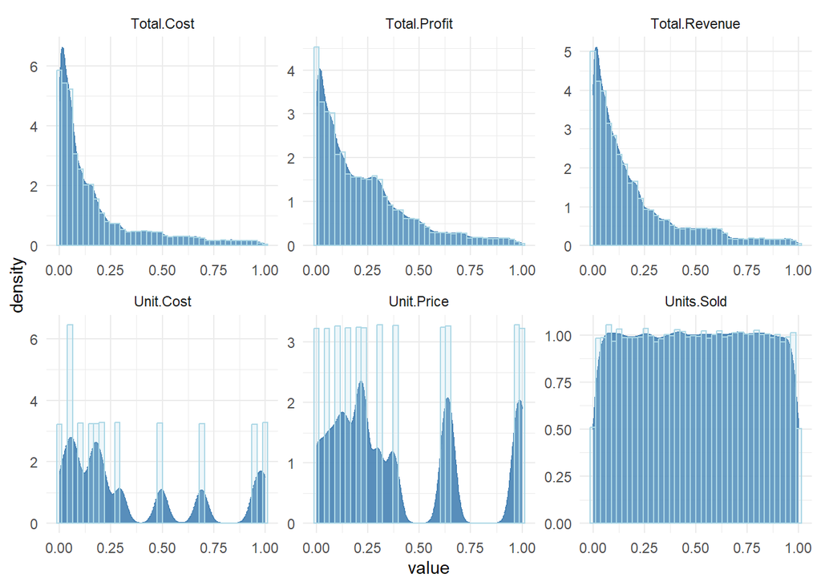

```r
#distribution
df100k_norm %>%
  gather(variable, value, 1:6) %>%
  ggplot(aes(value)) +
    facet_wrap(~variable, scales = "free") +
    geom_density(fill = "steelblue", alpha=0.9, color="steelblue") +
    geom_histogram(aes(y=after_stat(density)), alpha=0.2, fill = "lightblue",
                   color="lightblue", position="identity", bins = 40) +
    theme_minimal()
```

# Models

## Simple Linear Regression

The first model created is a simple linear regression using the normalized numeric data for the 1k dataset.

First the data is split into a train and test sets.

```r
set.seed(146)

training.samples3 <- df1k_norm$Total.Revenue %>%
  createDataPartition(p = 0.8, list = FALSE)
train.data3  <- df1k_norm[training.samples3, ]
test.data3 <- df1k_norm[-training.samples3, ]
```

Next, the model is run using the predictor variable, `Units.Sold` identified in the EDA stage from the VIF Scores calculated.

The model performs terribly with an R-squared value of .268

```r
model3<- lm(Total.Revenue~Units.Sold, data=train.data3 )

summary(model3)
```

```
##
## Call:
## lm(formula = Total.Revenue ~ Units.Sold, data = train.data3)
##
## Residuals:
##      Min       1Q   Median       3Q      Max
## -0.39003 -0.11942 -0.02423  0.08463  0.59651
##
## Coefficients:
##             Estimate Std. Error t value Pr(>|t|)
## (Intercept) -0.00610    0.01367  -0.446    0.655
## Units.Sold   0.41357    0.02340  17.671   <2e-16 ***
## ---
## Signif. codes:  0 '***' 0.001 '**' 0.01 '*' 0.05 '.' 0.1 ' ' 1
##
## Residual standard error: 0.1944 on 798 degrees of freedom
## Multiple R-squared:  0.2812, Adjusted R-squared:  0.2803
## F-statistic: 312.2 on 1 and 798 DF,  p-value: < 2.2e-16
```

```r
# Make predictions
predictions3 <- model3 %>% predict(test.data3)

# Model performance
data.frame(
  RMSE = RMSE(predictions3, test.data3$Total.Revenue),
  R2 = R2(predictions3, test.data3$Total.Revenue)
)
```

```
##        RMSE      R2
## 1 0.1767821 0.26836
```

```r
set.seed(146)

training.samples4 <- df100k_norm$Total.Revenue %>%
  createDataPartition(p = 0.8, list = FALSE)
train.data4  <- df1k_norm[training.samples4, ]
test.data4 <- df1k_norm[-training.samples4, ]
```

```r
model4<- lm(Total.Revenue~Units.Sold, data=train.data4)

summary(model4)
```

```
##
## Call:
## lm(formula = Total.Revenue ~ Units.Sold, data = train.data4)
##
## Residuals:
##      Min       1Q   Median       3Q      Max
## -0.38290 -0.11789 -0.02670  0.08674  0.59611
##
## Coefficients:
##              Estimate Std. Error t value Pr(>|t|)
## (Intercept) -0.003536   0.013220  -0.267    0.789
## Units.Sold   0.408044   0.022883  17.832   <2e-16 ***
## ---
## Signif. codes:  0 '***' 0.001 '**' 0.01 '*' 0.05 '.' 0.1 ' ' 1
##
## Residual standard error: 0.1892 on 801 degrees of freedom
##   (79198 observations deleted due to missingness)
## Multiple R-squared:  0.2842, Adjusted R-squared:  0.2833
## F-statistic:   318 on 1 and 801 DF,  p-value: < 2.2e-16
```

```r
# Make predictions
predictions4 <- model4 %>% predict(test.data4)

# Model performance
data.frame(
  RMSE = RMSE(predictions4, test.data4$Total.Revenue),
  R2 = R2(predictions4, test.data4$Total.Revenue)
)
```

```
##        RMSE        R2
## 1 0.1977754 0.2595009
```

## Multiple Linear Regression

For the next model, additional predictor variables are incorporated in the `lm()` function to generate a multiple linear regression model for both the 1k and 100k datasets.

First step is to narrow down the variables of the 1k dataset to be used and then preprocess the numeric values to create the model.

```r
df1k2 <- df1k %>%
  # purrr::discard(is.numeric) %>%
  select(-c(Country, Unit.Cost, Unit.Price, Total.Cost, Total.Profit, Order.ID))

preproc1 <-preProcess(df1k2, method=c("center", "scale"))
norm1 <- predict(preproc1,df1k2)
head(norm1)
```

```
##                         Region  Item.Type Sales.Channel Order.Priority
## 1 Middle East and North Africa  Cosmetics       Offline              M
## 2                North America Vegetables        Online              M
## 3 Middle East and North Africa  Baby Food       Offline              C
## 4                         Asia     Cereal       Offline              C
## 5           Sub-Saharan Africa     Fruits       Offline              H
## 6                       Europe     Cereal        Online              H
##   Order.Date  Ship.Date Units.Sold Total.Revenue
## 1 2014-10-18 2014-10-31  1.1691049     1.5911512
## 2 2011-11-07 2011-12-08 -0.7017320    -0.5801280
## 3 2016-10-31 2016-12-09 -1.2190729    -0.6323935
## 4 2010-04-10 2010-05-12 -0.5969541    -0.4332191
## 5 2011-08-16 2011-08-31  1.6512900    -0.8311173
## 6 2014-11-24 2014-12-28  1.5420315     0.4255510
```

```r
set.seed(146)

training.samples5 <- norm1$Total.Revenue %>%
  createDataPartition(p = 0.8, list = FALSE)
train.data5  <- norm1[training.samples5, ]
test.data5 <- norm1[-training.samples5, ]
```

```r
model5<- lm(Total.Revenue~., data=train.data5 )

summary(model5)
```

```
##
## Call:
## lm(formula = Total.Revenue ~ ., data = train.data5)
##
## Residuals:
##      Min       1Q   Median       3Q      Max
## -1.30940 -0.24092 -0.00256  0.26625  1.32082
##
## Coefficients:
##                                           Estimate Std. Error t value Pr(>|t|)
## (Intercept)                              0.4507895  0.3326560   1.355   0.1758
## RegionAustralia and Oceania              0.0992314  0.0737415   1.346   0.1788
## RegionCentral America and the Caribbean  0.0736127  0.0666352   1.105   0.2696
## RegionEurope                             0.0986397  0.0532508   1.852   0.0644
## RegionMiddle East and North Africa       0.1179443  0.0621355   1.898   0.0580
## RegionNorth America                      0.2755912  0.1243917   2.216   0.0270
## RegionSub-Saharan Africa                 0.0596160  0.0546291   1.091   0.2755
## Item.TypeBeverages                      -0.7006078  0.0722228  -9.701  < 2e-16
## Item.TypeCereal                         -0.1693776  0.0800262  -2.117   0.0346
## Item.TypeClothes                        -0.4832633  0.0796803  -6.065 2.06e-09
## Item.TypeCosmetics                       0.6930714  0.0778951   8.898  < 2e-16
## Item.TypeFruits                         -0.8090359  0.0806698 -10.029  < 2e-16
## Item.TypeHousehold                       1.3651836  0.0774116  17.635  < 2e-16
## Item.TypeMeat                            0.5703706  0.0802361   7.109 2.66e-12
## Item.TypeOffice Supplies                 1.3564537  0.0743473  18.245  < 2e-16
## Item.TypePersonal Care                  -0.6576760  0.0753363  -8.730  < 2e-16
## Item.TypeSnacks                         -0.3231962  0.0762530  -4.238 2.52e-05
## Item.TypeVegetables                     -0.3370095  0.0736099  -4.578 5.46e-06
## Sales.ChannelOnline                      0.0264275  0.0321730   0.821   0.4117
## Order.PriorityH                         -0.0114432  0.0460630  -0.248   0.8039
## Order.PriorityL                         -0.0092059  0.0448840  -0.205   0.8375
## Order.PriorityM                         -0.0491361  0.0451238  -1.089   0.2765
## Order.Date                              -0.0003623  0.0011054  -0.328   0.7432
## Ship.Date                                0.0003272  0.0011060   0.296   0.7674
## Units.Sold                               0.5323077  0.0158651  33.552  < 2e-16
##
## (Intercept)
## RegionAustralia and Oceania
## RegionCentral America and the Caribbean
## RegionEurope                            .
```

[output cut: 12 more lines]

```
## Item.TypeSnacks                         ***
## Item.TypeVegetables                     ***
## Sales.ChannelOnline
## Order.PriorityH
## Order.PriorityL
## Order.PriorityM
## Order.Date
## Ship.Date
## Units.Sold                              ***
## ---
## Signif. codes:  0 '***' 0.001 '**' 0.01 '*' 0.05 '.' 0.1 ' ' 1
##
## Residual standard error: 0.4472 on 775 degrees of freedom
## Multiple R-squared:  0.8134, Adjusted R-squared:  0.8076
## F-statistic: 140.7 on 24 and 775 DF,  p-value: < 2.2e-16
```

```r
# Make predictions
predictions5 <- model5 %>% predict(test.data5)

# Model performance
data.frame(
  RMSE = RMSE(predictions5, test.data5$Total.Revenue),
  R2 = R2(predictions5, test.data5$Total.Revenue)
)
```

```
##        RMSE        R2
## 1 0.4052013 0.8063358
```

A significant improvement in the accuracy of the model is shown by the R squared value which is now 0.81.

Next is the multiple linear regression model for the 100k dataset.

```r
df100k2 <- df100k %>%
  # purrr::discard(is.numeric) %>%
  select(-c(Country, Unit.Cost, Unit.Price, Total.Cost, Total.Profit, Order.ID))

preproc2 <-preProcess(df100k2, method=c("center", "scale"))
norm2 <- predict(preproc2,df100k2)
head(norm2)
```

```
##                              Region     Item.Type Sales.Channel Order.Priority
## 1      Middle East and North Africa        Snacks        Online              C
## 2 Central America and the Caribbean     Cosmetics       Offline              L
## 3                Sub-Saharan Africa        Fruits       Offline              M
## 4                Sub-Saharan Africa Personal Care        Online              M
## 5 Central America and the Caribbean     Household       Offline              H
## 6                            Europe       Clothes        Online              C
##   Order.Date  Ship.Date Units.Sold Total.Revenue
## 1 2014-10-08 2014-10-23 -1.4100675    -0.8109684
## 2 2015-02-22 2015-02-27 -0.1561568     0.4441126
## 3 2015-12-09 2016-01-18  1.7280026    -0.8444929
## 4 2014-09-17 2014-10-12  1.4270918    -0.4014578
## 5 2010-02-04 2010-03-05  0.2969428     1.7520830
## 6 2013-02-20 2013-02-28 -1.3355332    -0.8224831
```

```r
set.seed(147)

training.samples6 <- norm2$Total.Revenue %>%
  createDataPartition(p = 0.8, list = FALSE)
train.data6  <- norm2[training.samples6, ]
test.data6 <- norm2[-training.samples6, ]
```

```r
model6<- lm(Total.Revenue~., data=train.data6 )

summary(model6)
```

```
##
## Call:
## lm(formula = Total.Revenue ~ ., data = train.data6)
##
## Residuals:
##      Min       1Q   Median       3Q      Max
## -1.36875 -0.24459  0.00064  0.24408  1.37280
##
## Coefficients:
##                                           Estimate Std. Error  t value Pr(>|t|)
## (Intercept)                             -6.434e-02  3.102e-02   -2.074   0.0381
## RegionAustralia and Oceania              4.995e-03  6.556e-03    0.762   0.4461
## RegionCentral America and the Caribbean  1.073e-02  6.035e-03    1.779   0.0753
## RegionEurope                             2.540e-03  4.912e-03    0.517   0.6052
## RegionMiddle East and North Africa       1.011e-02  5.771e-03    1.751   0.0799
## RegionNorth America                     -5.835e-03  1.104e-02   -0.529   0.5971
## RegionSub-Saharan Africa                 8.553e-03  4.912e-03    1.741   0.0816
## Item.TypeBeverages                      -7.145e-01  7.373e-03  -96.905   <2e-16
## Item.TypeCereal                         -1.696e-01  7.341e-03  -23.099   <2e-16
## Item.TypeClothes                        -4.982e-01  7.354e-03  -67.753   <2e-16
## Item.TypeCosmetics                       6.185e-01  7.343e-03   84.229   <2e-16
## Item.TypeFruits                         -8.262e-01  7.383e-03 -111.907   <2e-16
## Item.TypeHousehold                       1.402e+00  7.363e-03  190.428   <2e-16
## Item.TypeMeat                            5.691e-01  7.361e-03   77.318   <2e-16
## Item.TypeOffice Supplies                 1.350e+00  7.340e-03  183.900   <2e-16
## Item.TypePersonal Care                  -5.820e-01  7.346e-03  -79.231   <2e-16
## Item.TypeSnacks                         -3.506e-01  7.354e-03  -47.671   <2e-16
## Item.TypeVegetables                     -3.427e-01  7.342e-03  -46.672   <2e-16
## Sales.ChannelOnline                      5.199e-04  3.000e-03    0.173   0.8624
## Order.PriorityH                          2.478e-04  4.249e-03    0.058   0.9535
## Order.PriorityL                          6.703e-04  4.242e-03    0.158   0.8745
## Order.PriorityM                          7.818e-03  4.237e-03    1.845   0.0650
## Order.Date                               2.442e-05  1.017e-04    0.240   0.8101
## Ship.Date                               -2.337e-05  1.016e-04   -0.230   0.8181
## Units.Sold                               5.218e-01  1.500e-03  347.935   <2e-16
##
## (Intercept)                             *
## RegionAustralia and Oceania
## RegionCentral America and the Caribbean .
## RegionEurope
```

[output cut: 12 more lines]

```
## Item.TypeSnacks                         ***
## Item.TypeVegetables                     ***
## Sales.ChannelOnline
## Order.PriorityH
## Order.PriorityL
## Order.PriorityM                         .
## Order.Date
## Ship.Date
## Units.Sold                              ***
## ---
## Signif. codes:  0 '***' 0.001 '**' 0.01 '*' 0.05 '.' 0.1 ' ' 1
##
## Residual standard error: 0.4242 on 79976 degrees of freedom
## Multiple R-squared:  0.8197, Adjusted R-squared:  0.8197
## F-statistic: 1.515e+04 on 24 and 79976 DF,  p-value: < 2.2e-16
```

```r
# Make predictions
predictions6 <- model6 %>% predict(test.data6)

# Model performance
data.frame(
  RMSE = RMSE(predictions6, test.data6$Total.Revenue),
  R2 = R2(predictions6, test.data6$Total.Revenue)
)
```

```
##        RMSE        R2
## 1 0.4257115 0.8203291
```

# Essay

Develop your exploratory analysis of the data and the essay in the following 2 weeks.

# References

[^1]: https://cran.r-project.org/web/packages/labelled/vignettes/intro_labelled.html
[^2]: https://stats.oarc.ucla.edu/r/modules/factor-variables/#:~:text=Perhaps%20the%20most%20important%20advantage,many%20different%20types%20of%20graphics.
[^3]: https://www.ncbi.nlm.nih.gov/pmc/articles/PMC4888898/
[^4]: http://www.sthda.com/english/articles/39-regression-model-diagnostics/160-multicollinearity-essentials-and-vif-in-r/
[^5]: https://www.statology.org/how-to-normalize-data-in-r/